# R ToolBox

Mingjun Sun

4/26/2017

# The question I would like to answer using the dataset

Nowadays, film has become an indispensable part of our lives. Film is considered as an important art form, a medium for educating and representation of different cultures. However, filmmaking is costly and risky, so profit is a key element in the industry. Because I am a big fan of film and one of my undergraduate majors is Finance, I want to support my interests by practicing finance knowledge and data analytics. For this project, I would like to build a predictive model based on my dataset. The model can be used to predict the revenue of an upcoming movie. Based on the predicted revenue, investors and directors can better estimate budget by selecting actors or choosing appropriate advertising plans to avoid cost overruns.

# Dataset information

```r
df <- read.csv("~/Desktop/R Final/Movie Data.csv",
               header=T, sep=",", stringsAsFactors = F)
View(df)
```

I collected my dataset from a data platform called Kaggle. My dataset contains 5043 movies from 1916 to 2016. After removing some irrelevant information like IMDB website links and movie keywords, I have 24 variables left for the outcome variable, “gross profit”, which represents the total profit of all ticket sales. Here are the variables: names of movies, directors and actors, Facebook likes for directors, actors, cast members and movies, number of voted users, number of reviews, number of critical reviews, color, duration, face number in poster, language, country, content rating, budget, year, IMDB score and aspect ratio. The variable, “aspect ratio”, is the picture size of a movie; usually we have Normal Size (4:3) and Wide Screen (16:9). Besides this variable, others can be literally understood by their names.

# Data cleaning

## Missing values

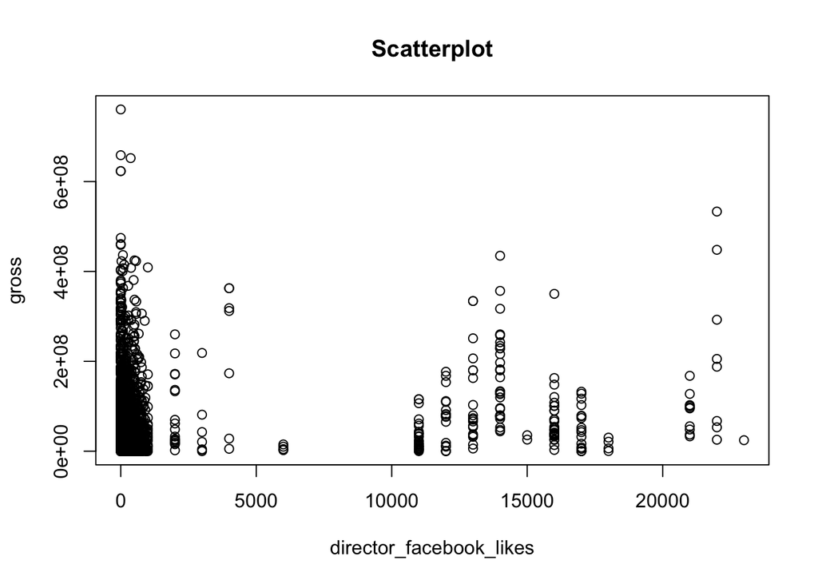

```r
plot(df$director_facebook_likes, df$gross,
     main="Scatterplot",
     xlab="director_facebook_likes",
     ylab="gross")
```

```r
summary(df$director_facebook_likes)
```

```
##    Min. 1st Qu.  Median    Mean 3rd Qu.    Max.    NA's
##     0.0     7.0    49.0   686.5   194.5 23000.0     104
```

```r
df$director_facebook_likes <- NULL
```

## Unreachable data

```r
df$movie_facebook_likes <- NULL
df$num_voted_users <- NULL
```

Some variables in my dataset are not available before a movie being released. Thus, variables such as “movie facebook likes” and “number of voted users” should be removed from a predictive model.

## Outliers

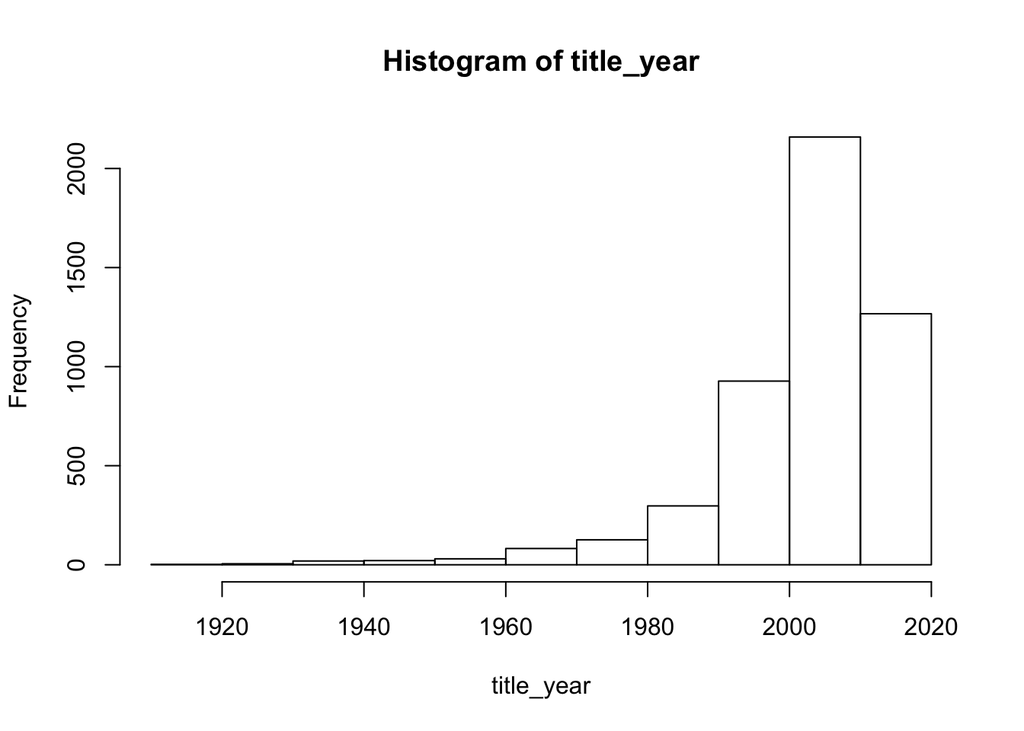

```r
hist(df$title_year, main = "Histogram of title_year",
     xlab = "title_year",
     breaks = 10)
```

```r
summary(df$title_year)
```

```
##    Min. 1st Qu.  Median    Mean 3rd Qu.    Max.    NA's
##    1916    1999    2005    2002    2011    2016     108
```

```r
df <- df[df$title_year>=1970,]
```

I notice that some movies in my dataset have missing variables due to lack of information. For instance, a couple of movies from 1920s do not have data for gross profit and budget. Most movies before 1970s was unrated. I have 147 movies released before 1970. As we can see from the variable distribution, these movies only take up 2.5% of the dataset. Considering factors relating to film history like technique development, movies before 1970s can be recognized as outliers. I will remove them and only include movies with complete data in my model to ensure accuracy and correctness.

## Dummy variable

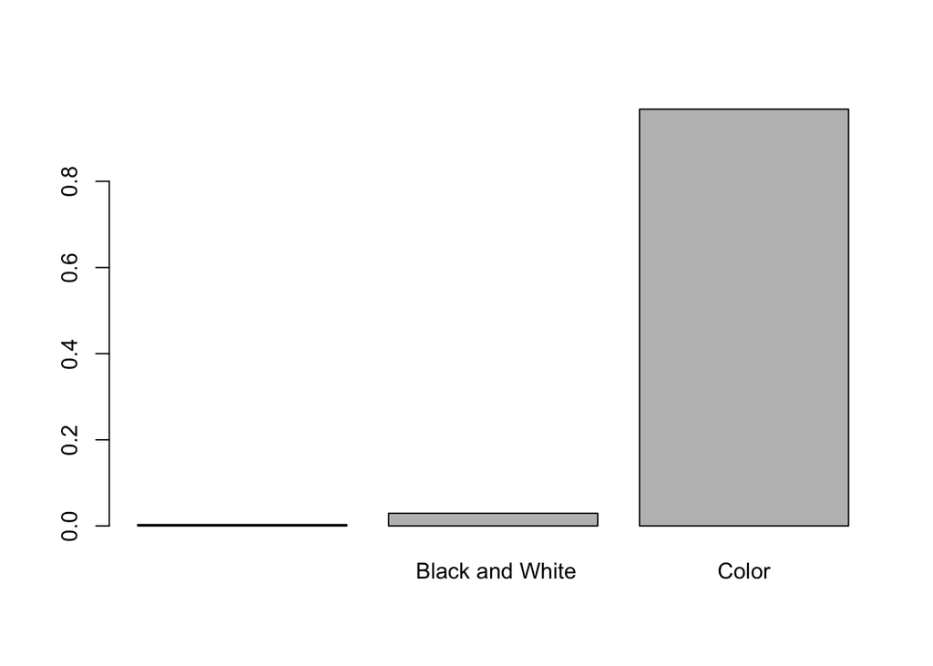

```r
barplot(prop.table(table(df$color)))
```

```r
df$color <- NULL
```

## String variable

```r
df$language <- ifelse(df$language =="English", 1, 0)

df$content_rating[df$content_rating == "R"] <- 2
df$content_rating[df$content_rating == "PG-13"] <- 1
df$content_rating[df$content_rating != 2 & df$content_rating != 1] <- 0
```

The original dataset contains some non-numeric values, such as “language” and “content rating”. It makes sense that these two variables can affect a movie’s gross profit, so I converted these string variables into numeric variables. Even though over 95% of the movies in my dataset are presented in English, I would still like to include “language” in my model since English movies are accepted internationally, and therefore stimulate worldwide box office profit. I changed “language” to a dummy variable in my model. For “content rating”, I converted it into numeric variable by putting “2” for R - Restricted, “1” for PG-13 – Parental Strongly Cautioned and “0” for other film ratings. Restricted movies contain some adult material and young children under 17 require accompanying parent or adult guardian. Movies rated as “R” should have lower profits compare to other movie types due to the loss of some teenager audience.

## Illogical information

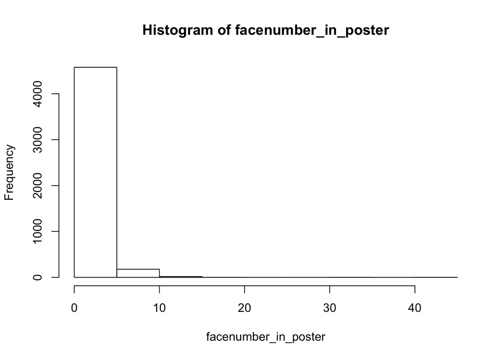

```r
hist(df$facenumber_in_poster,
     main = "Histogram of facenumber_in_poster",
     xlab = "facenumber_in_poster",
     breaks = 10)
```

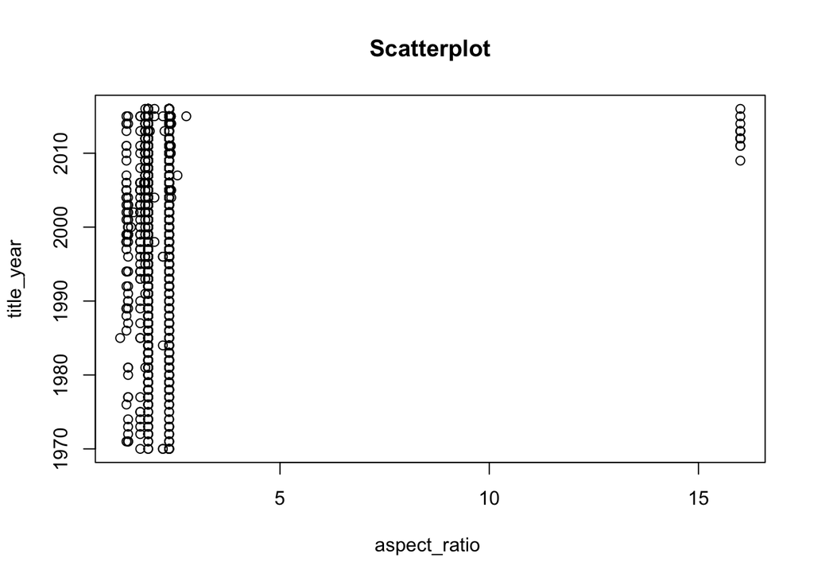

```r
df$facenumber_in_poster <- NULL

plot(df$aspect_ratio, df$title_year,
     main="Scatterplot",
     xlab="aspect_ratio ", ylab="title_year")
```

```r
df$aspect_ratio <- NULL
```

## Correlation

```r
cor(df[,c("actor_1_facebook_likes",
          "actor_2_facebook_likes",
          "actor_3_facebook_likes")],
    use="na.or.complete")
```

```
##                        actor_1_facebook_likes actor_2_facebook_likes
## actor_1_facebook_likes              1.0000000              0.3871774
## actor_2_facebook_likes              0.3871774              1.0000000
## actor_3_facebook_likes              0.2469324              0.5579042
##                        actor_3_facebook_likes
## actor_1_facebook_likes              0.2469324
## actor_2_facebook_likes              0.5579042
## actor_3_facebook_likes              1.0000000
```

```r
df$actor_total_facebook_likes <- rowSums(df[,c("actor_1_facebook_likes",
                                               "actor_2_facebook_likes",
                                               "actor_3_facebook_likes")],
                                         na.rm=F, dims =1)

df[,c("actor_1_facebook_likes",
      "actor_2_facebook_likes",
      "actor_3_facebook_likes")] <- NULL
```

From the correlation matrix, “actor 1 facebook likes”, “actor 2 facebook likes” and “actor 3 facebook likes” have positive correlation among each other, which means an increase of any one of the three variables will cause the other two to increase as well. Since I decided not to drop these three variables, I would like to combine them by creating a new column called “actor total facebook likes”.

# Linear Regression Model

```r
df$country <- as.numeric(as.factor(df$country))

lm1 <- lm(gross ~ ., data = df)
summary(lm1)
```

```
##
## Call:
## lm(formula = gross ~ ., data = df)
##
## Residuals:
##        Min         1Q     Median         3Q        Max
## -253258686  -27303957   -5527465   16877811  452475304
##
## Coefficients:
##                              Estimate Std. Error t value Pr(>|t|)
## (Intercept)                 1.542e+09  2.445e+08   6.305 3.20e-10 ***
## num_critic_for_reviews      1.496e+05  1.005e+04  14.889  < 2e-16 ***
## duration                    1.569e+05  4.151e+04   3.779 0.000160 ***
## cast_total_facebook_likes   9.798e+03  5.854e+02  16.736  < 2e-16 ***
## num_user_for_reviews        5.754e+04  2.632e+03  21.863  < 2e-16 ***
## language                    2.191e+07  4.377e+06   5.006 5.80e-07 ***
## country                     2.748e+05  6.178e+04   4.448 8.90e-06 ***
## content_rating1            -2.025e+07  2.346e+06  -8.632  < 2e-16 ***
## content_rating2            -4.812e+07  2.195e+06 -21.917  < 2e-16 ***
## budget                      1.299e-02  3.661e-03   3.547 0.000395 ***
## title_year                 -7.913e+05  1.212e+05  -6.528 7.54e-11 ***
## imdb_score                  2.341e+06  9.180e+05   2.550 0.010808 *
## actor_total_facebook_likes -9.739e+03  6.007e+02 -16.213  < 2e-16 ***
## ---
## Signif. codes:  0 '***' 0.001 '**' 0.01 '*' 0.05 '.' 0.1 ' ' 1
##
## Residual standard error: 49830000 on 3819 degrees of freedom
##   (1064 observations deleted due to missingness)
## Multiple R-squared:  0.4958, Adjusted R-squared:  0.4942
## F-statistic: 312.9 on 12 and 3819 DF,  p-value: < 2.2e-16
```

## Invite famous actors

```r
lm2 <- lm(gross ~ actor_total_facebook_likes,
          data = df)
summary(lm2)
```

```
##
## Call:
## lm(formula = gross ~ actor_total_facebook_likes, data = df)
##
## Residuals:
##        Min         1Q     Median         3Q        Max
## -513991604  -39198822  -22496553   13032615  717956532
##
## Coefficients:
##                             Estimate Std. Error t value Pr(>|t|)
## (Intercept)                4.017e+07  1.199e+06   33.52   <2e-16 ***
## actor_total_facebook_likes 8.518e+02  5.791e+01   14.71   <2e-16 ***
## ---
## Signif. codes:  0 '***' 0.001 '**' 0.01 '*' 0.05 '.' 0.1 ' ' 1
##
## Residual standard error: 66980000 on 4092 degrees of freedom
##   (802 observations deleted due to missingness)
## Multiple R-squared:  0.05022,    Adjusted R-squared:  0.04998
## F-statistic: 216.3 on 1 and 4092 DF,  p-value: < 2.2e-16
```

The linear regression model supports my recommendation that with 1 increase of Facebook likes of the top three actors/actresses in a movie, that movie’s revenue is expected to increase by $852 in average. This new variable has a low p-value and positive lower 95% and upper 95% significant levels, supporting the idea that activeness of an actor/actress on social media has an advantageous effect on his/her recently released movie. Filmmaking teams, including directors, actors and other movie crews, benefit from having members who achieve high individual performance. Stars’ contributions could directly increase the team’s performance but may also indirectly drive success, for example, by enhancing the group’s perceived standing in the eyes of external constituents.

## Increase budgets within an acceptable range

```r
lm3 <- lm(gross ~ budget,
          data = df)
summary(lm3)
```

```
##
## Call:
## lm(formula = gross ~ budget, data = df)
##
## Residuals:
##        Min         1Q     Median         3Q        Max
## -437696690  -43427676  -22446691   14441584  703177885
##
## Coefficients:
##              Estimate Std. Error t value Pr(>|t|)
## (Intercept) 4.976e+07  1.147e+06  43.384  < 2e-16 ***
## budget      3.194e-02  5.023e-03   6.358 2.28e-10 ***
## ---
## Signif. codes:  0 '***' 0.001 '**' 0.01 '*' 0.05 '.' 0.1 ' ' 1
##
## Residual standard error: 69660000 on 3841 degrees of freedom
##   (1053 observations deleted due to missingness)
## Multiple R-squared:  0.01041,    Adjusted R-squared:  0.01016
## F-statistic: 40.42 on 1 and 3841 DF,  p-value: 2.283e-10
```

According to Parameter Estimates Table, 1 dollar increase in movie budget will only cause the gross profit to rise by $0.032. This variable’s rate of return is low compares to others’. I have to adjust my recommendation based on the linear regression result. Even though we have movies like “Avatar” which has historical high budgets and makes 6 times more worldwide gross revenues, lots of movies lose money due to expensive producing costs. Honestly speaking, the goal for filmmaking companies is to make money, not perfect movies. Instead of simply increasing budgets to improve the quality of movies, they should pay more attention to profit margin and increase budgets within an acceptable range.

## An effective marketing plan

```r
lm4 <- lm(gross ~ imdb_score,
          data = df)
summary(lm4)
```

```
##
## Call:
## lm(formula = gross ~ imdb_score, data = df)
##
## Residuals:
##       Min        1Q    Median        3Q       Max
## -74962254 -42949665 -17534631  16087055 692615385
##
## Coefficients:
##              Estimate Std. Error t value Pr(>|t|)
## (Intercept) -37405918    6556903  -5.705 1.25e-08 ***
## imdb_score   13328656    1002758  13.292  < 2e-16 ***
## ---
## Signif. codes:  0 '***' 0.001 '**' 0.01 '*' 0.05 '.' 0.1 ' ' 1
##
## Residual standard error: 67240000 on 4104 degrees of freedom
##   (790 observations deleted due to missingness)
## Multiple R-squared:  0.04127,    Adjusted R-squared:  0.04104
## F-statistic: 176.7 on 1 and 4104 DF,  p-value: < 2.2e-16
```

The linear regression model prove my hypothesis that an effective marketing plan has a positive influence on the profitability of a movie. The linear regression model indicates that with 1 point increase of IMDB score, the gross profits will increase by $13328656 in average. Because the money earned during the first weekend of a movie’s release is the most important indicator of the advertising success, an effective film marketing plan should be able to maximize awareness of the movie and to attract people the movie is aimed at.

# Conclusion

Although we can only find out linear relationships between dependent and independent variables using linear regression model, its concise and explicit ways of expression can be easily understood by filmmaking business managers and help them to achieve their financial goals by inviting famous actors, increasing budgets with an acceptable range and building effective marketing plans.